# Capstone Project -- Weather Prediction

You will be provided a dataset that contains daily weather conditions at 98 airports over a ten year period, January 1 2005 -- December 31 2014.

The 98 airports are:

ABQ AIY ALB AMA ATL AUS BFL BHM BIS BMG BNA BOS BTR BUF BWI BZN CHA CHS CLE CLL CLT CMI COS CRW CVG DEN DFW DLH DSM DTW EKO ELP EUG EYW FAR FLG FLL FNT FOE FSD GEG GJT GNV GRB GRR HFD HOU IAD ILG IND LAN LAS LAX LCK LGA LIT LNK MAF MCI MCO MEM MIA MKE MOB MOT MSN MSP MYR OAK OKC OLM OMA ORD PDX PHL PHX PIT PVD RAP RDU RFD RIC RNO SAN SAT SAV SDF SEA SFO SLC STL SUX TLH TTN TUL TUS TVC UNV

Your goal is to build models to predict

- daily max temperature
- daily mean temperature
- daily min temperature

at the following 15 airports

- ABQ
- ATL
- BOS
- DEN
- DFW
- DLH
- DTW
- EYW
- IAD
- LAN
- LAX
- SEA
- SFO
- SLC
- TVC

for 1--5 days into the future.

More specifically, once you have completed building your predictive models, you will be given data from a "validation" year (a year other than 2005--2014). For each month in the validation year, you will be given data from days 1--15 of that month and will be asked to predict temperatures for days 16--20. Thus, in total you will make (3 temperatures) $\times$ (15 airports) $\times$ (12 months) $\times$ (5 days) = 2700 predictions. Your goal is to minimize the MSE of your predictions.

You will complete the project in groups of 3 or 4. You can use any methods / models covered in this course. Your code must be finalized and shared via github before you are given the validation data. You will give a short (10 minute) presentation in class on the approach you used. Your presentation should include:

- Any EDA you found particularly relevant  
  (remember, everyone has the same data, so no need to give a general overview)
- A description of how / why you chose your final models
- A description of your final models
- An evaluation of your models, and your expected MSE  
  (perhaps broken down by airport, or by time of year, or by prediction day (1--5)
- Anything else you find relevant / interesting

You will also submit a brief (3 page max) written report describing your work (which may reference figures in the slides). The report should also include the final performance on the validation data, and brief discussion of what went right/wrong.

Timeline:

- 11/3: Form groups
- 12/2: Code finalized
- 12/3: Presentations in class
- 12/3: Validation data released
- 12/7: Deadline to submit predictions (by noon, please)
- 12/10: Written report due

# Data

```r
load("weather.rda")
str(weather)
```

```
'data.frame':	3652 obs. of  2156 variables:
 $ DTW_Max.TemperatureF         : int  39 54 39 36 32 28 28 30 34 36 ...
 $ DTW_Mean.TemperatureF        : int  34 43 37 34 28 24 22 28 31 34 ...
 $ DTW_Min.TemperatureF         : int  28 32 35 32 23 21 17 26 28 33 ...
 $ DTW_Max.Dew.PointF           : int  31 54 36 34 28 27 25 27 31 32 ...
 $ DTW_MeanDew.PointF           : int  25 42 35 31 23 22 21 25 28 28 ...
 $ DTW_Min.DewpointF            : int  20 30 33 28 19 17 16 23 24 25 ...
 $ DTW_Max.Humidity             : int  96 100 100 96 93 100 93 96 92 93 ...
 $ DTW_Mean.Humidity            : int  72 97 92 87 87 85 85 86 86 78 ...
 $ DTW_Min.Humidity             : int  54 89 89 79 74 69 77 72 79 67 ...
 $ DTW_Max.Sea.Level.PressureIn : num  30.5 30.4 30.4 30.4 30.3 ...
 $ DTW_Mean.Sea.Level.PressureIn: num  30.4 30.2 30.3 30.3 30.2 ...
 $ DTW_Min.Sea.Level.PressureIn : num  30.2 30.2 30.2 30.2 30 ...
 $ DTW_Max.VisibilityMiles      : int  10 10 10 10 10 10 10 10 10 10 ...
 $ DTW_Mean.VisibilityMiles     : int  10 4 6 10 3 5 10 6 9 9 ...
```

[output cut: 86 more lines]

```r
for (i in 1:22) print(summary(weather[i]))
```

```
 DTW_Max.TemperatureF
 Min.   : -1.00
 1st Qu.: 41.00
 Median : 62.00
 Mean   : 59.49
 3rd Qu.: 78.00
 Max.   :102.00
 DTW_Mean.TemperatureF
 Min.   :-7.00
 1st Qu.:35.00
 Median :52.00
 Mean   :51.06
 3rd Qu.:68.00
 Max.   :90.00
 DTW_Min.TemperatureF
 Min.   :-15.00
 1st Qu.: 28.00
 Median : 43.00
 Mean   : 42.17
 3rd Qu.: 58.00
 Max.   : 80.00
 DTW_Max.Dew.PointF
 Min.   :-8.00
 1st Qu.:31.00
 Median :47.00
 Mean   :45.25
 3rd Qu.:61.00
 Max.   :79.00
 DTW_MeanDew.PointF
 Min.   :-14.00
 1st Qu.: 26.00
 Median : 40.00
 Mean   : 39.91
 3rd Qu.: 55.00
 Max.   : 75.00
 DTW_Min.DewpointF
 Min.   :-22.00
 1st Qu.: 20.00
 Median : 33.00
 Mean   : 34.02
```

[output cut: 102 more lines]

```
             DTW_Events
                  :1774
 Rain             : 796
 Snow             : 446
 Rain-Thunderstorm: 272
 Rain-Snow        : 113
 Fog-Snow         :  71
 (Other)          : 180
 DTW_WindDirDegrees
 Min.   :  1.0
 1st Qu.:122.0
 Median :208.0
 Mean   :193.7
 3rd Qu.:266.2
 Max.   :360.0
```

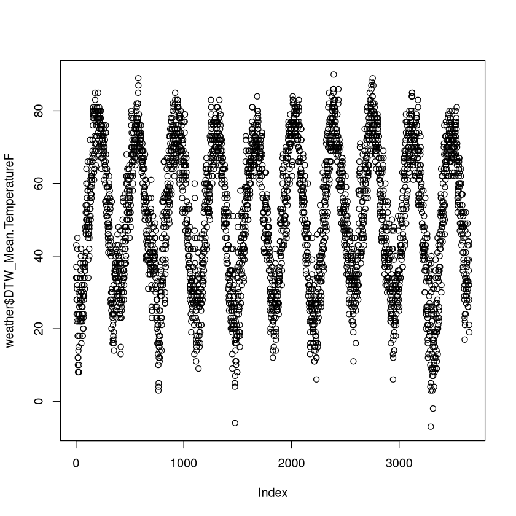

```r
plot(weather$DTW_Mean.TemperatureF)
```